# STA 141A: Predicting Wildfire Incidence in the United States

Kristine Ngo

## Abstract

Wildfires are one of the largest threats to our environment and forests, especially within the United States that is full of flush lands and trees. Prediction of such wildfires can help as a sort of preventative measure. Whether it be for better preparation, or ways to overall prevent the start of such damaging natural, and now, man-made disasters. To do so, this project is aimed at developing a prediction model for the incidence and location of notable wildfires in the United States. The notable wildfires will be predicted according to a created unit based on month (which month of the year) and state.

## Data and background

The Kaggle dataset, *“188 Million US Wildfires”* is a subset of historical wildfire records within the United States. In the database, there is recorded information on certain characteristics of the wildfires, such as, the date of discovery and containment, the cause of the wildfire, the type of land it occured on, and much more. Within the SQLite database, there is a table named “Fires” which contains data of wildfires from 1992 to 2015 in the United States.

The columns of the table from columns 1 to 19 are different ways of identifying the wildfire. Whether it be from where the data was sourced from, or what the wildfire incident was recorded as in that particular source. For example, columns such as those starting with ICA and NWCG that represent what the wildfires are recorded as in different the ICA and NWCG databases. Many of these columns are mostly blank despite being filled in other identifying columns. In the content description, `FOD_ID` is written as the global unique identifier for each fire. This means that this column contains the original number of each wildfire, and that none will be left out. Choosing this column will prevent any wildfires to be left out due to being represented in only certain databases. Thus, it feels it would be best to select the `FOD_ID` represent the fire’s identification.

The remaining eighteen identifying columns will be removed from the dataset to prevent confusion and allow focus on the columns that characterize the wildfires. To further shape the dataset, any missing values were removed as well.

Additional columns regarding the discovery date of the wildfires were added for better readability and easier data manipulation. One of the first columns, `FIRE_DATE` column was added as a date data type that combined the columns `FIRE_YEAR` and `DISCOVERY_DOY`. This was so that the date could be presented in a YYY-MM-DD format. A `MONTH` column was added for and the `FIRE_YEAR` column was converted from a integer data type to a double data type. Both changes were made for easier data manipulation with the date data type.

All of the changes were applied with the resulting dataframe “wf” that will be continouously used throughout the project and report.

```r
## set up dataset _____________________________________________________

# connect R with the sqlite database using path
wf_con <- dbConnect(RSQLite::SQLite(), "C://Users//KN//Downloads//STA 141//FPA_FOD_20170508.sqlite")

# assign all tables to a variable
tables <- dbListTables(wf_con)
# print out all tables within the sqlite
# tables

# select the table you want into a tibble
wf_fetus <- dbReadTable(wf_con, tables[2]) %>%
  as_tibble()
# check
# glimpse(wf_fetus)
# head(wf_fetus)

# remove undesired identification columns
wf <- wf_fetus %>%
  dplyr::select(-1, -(3:19))
# check
# glimpse(wf)
# head(wf)


## identify and remove NA values ______________________________________

# identify NA values from largest percentage
wf %>%
  # select only columns that have NA values
  dplyr::select(where(anyNA)) %>%
  # count number of NA values
  summarise(
    across(
      everything(),
      ~ sum(is.na(.))
    )
  ) %>%
  # change format of table for easier reading
  pivot_longer(cols = everything(),
               names_to = "Column",
               values_to = "NA Count") %>%
  # create new column to calculate percentages
  mutate(
    Percentage = `NA Count` / nrow(wf)
  ) %>%
  # order from largest percentage to lowest
  arrange(desc(Percentage))
```

```
## # A tibble: 7 × 3
##   Column         `NA Count` Percentage
##   <chr>               <int>      <dbl>
## 1 CONT_TIME          972173      0.517
## 2 CONT_DATE          891531      0.474
## 3 CONT_DOY           891531      0.474
## 4 DISCOVERY_TIME     882638      0.469
## 5 COUNTY             678148      0.361
## 6 FIPS_CODE          678148      0.361
## 7 FIPS_NAME          678148      0.361
```

```r
# remove outliers
wf <- wf %>%
  drop_na()
# check
all(!is.na(wf))
```

```
## [1] TRUE
```

```r
# glimpse(wf)
# head(wf)

## create column `MONTH` for the month when fire was discovered as a date data type

# create `FIRE_DATE` columns
# `FIRE_DATE`: date (date data type) that the fire was discovered
FIRE_DATE <- as.Date(paste(wf$`FIRE_YEAR`, wf$`DISCOVERY_DOY`), format = "%Y %j")
# check
# head(FIRE_DATE)

# create `MONTH` column for the month fire was discovered
MONTH <- month(FIRE_DATE)

# add columns to dataset
wf <- wf %>%
  mutate(
    `FIRE_DATE` = FIRE_DATE,
    `MONTH` = MONTH
  )
# check
# head(wf)

# create `YEAR` column for the year fire was discovered
wf$FIRE_YEAR <- year(`FIRE_DATE`)
# check
# head(wf)


# add column that considers if a fire is notable
wf <- wf %>%
  mutate(
    `IS_NOTABLE` = if_else(`FIRE_SIZE` >= 300, 1, 0)
  )
# check
head(wf)
```

```
## # A tibble: 6 × 24
##   FOD_ID FIRE_YEAR DISCOVERY_DATE DISCOVERY_DOY DISCOVERY_TIME STAT_CAUSE_CODE
##    <int>     <dbl>          <dbl>         <int> <chr>                    <dbl>
## 1      1      2005       2453404.            33 1300                         9
## 2      2      2004       2453138.           133 0845                         1
## 3      3      2004       2453156.           152 1921                         5
## 4      4      2004       2453184.           180 1600                         1
## 5      5      2004       2453184.           180 1600                         1
## 6      6      2004       2453186.           182 1800                         1
## # ℹ 18 more variables: STAT_CAUSE_DESCR <chr>, CONT_DATE <dbl>, CONT_DOY <int>,
## #   CONT_TIME <chr>, FIRE_SIZE <dbl>, FIRE_SIZE_CLASS <chr>, LATITUDE <dbl>,
## #   LONGITUDE <dbl>, OWNER_CODE <dbl>, OWNER_DESCR <chr>, STATE <chr>,
## #   COUNTY <chr>, FIPS_CODE <chr>, FIPS_NAME <chr>, Shape <blob>,
## #   FIRE_DATE <date>, MONTH <dbl>, IS_NOTABLE <dbl>
```

### 1. Data Preprocessing

This section explains how the raw wildfire data, “wf” was transformed into the final dataset “st_wf” used for modeling.

A notable wildfire will be identified according to whether its `FIRE_SIZE`, or estimation of acres within the final perimeter or the fire is greater than or equal to a certain threshold. The threshold is determined accordingly to whether the wildfire’s `FIRE_SIZE` is greater than or equal to 300 acres, as that is the size associated with large wildland fires as set by the standards used by U.S fire management agencies. A new column, `IS_NOTABLE` is created to display whether a wildfire is deemed notable (1), and not notable (0).

To measure the incidence of the wildfires, the `FIRE_SIZE`, and `NUMBER` were columns created to measure the median size (intensity) and number of wildfires (frequency) that occurred in each state. The values of both columns were graphed to determine their distribution. Since both the median size and number of the wildfires were heavily right-skewed and there were no zero values, it was decided to apply a log 10 transformation to each variable to normalize the distribution and stabilize the variance. This was done in hopes of improving the interpretability of the model by making potential patterns more noticeable and reducing the skewness by reducing the effect of extreme values such as outliers. The transformations were only applied when looking for patterns in graphs.

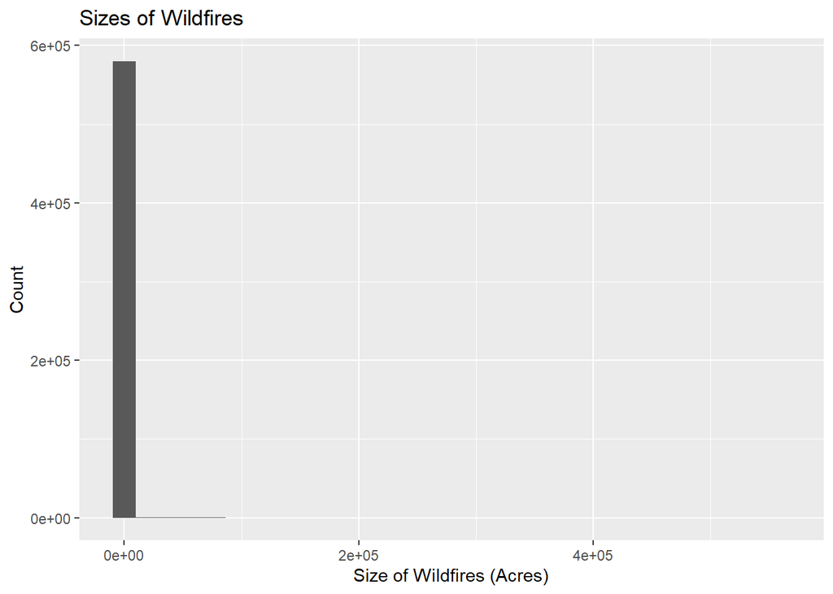

```r
## create histogram of intensity of fires to check the spread __________________

# create histogram
ggplot(wf, mapping = aes(
  x = `FIRE_SIZE`
)) +
  geom_histogram(bins = 30) +
  labs(
    title = "Sizes of Wildfires",
    x = "Size of Wildfires (Acres)",
    y = "Count"
  )
```

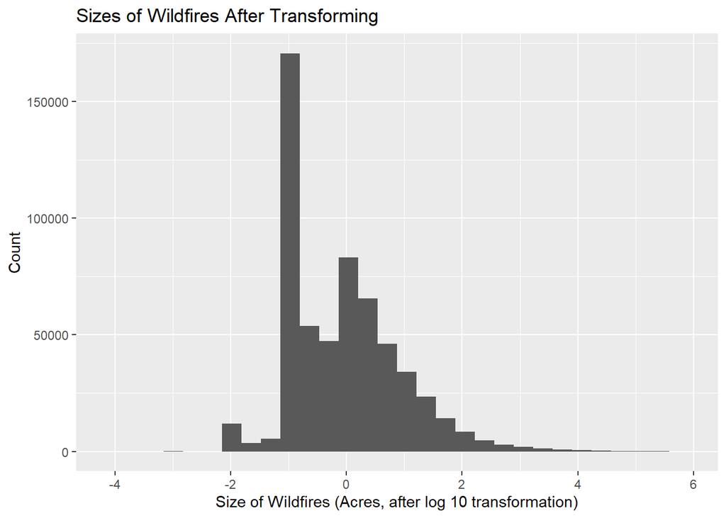

```r
# create histogram of log-transformed data
ggplot(wf, mapping = aes(
  x = log10(`FIRE_SIZE`)
)) +
  geom_histogram(bins = 30) +
  labs(
    title = "Sizes of Wildfires After Transforming",
    x = "Size of Wildfires (Acres, after log 10 transformation)",
    y = "Count"
  )
```

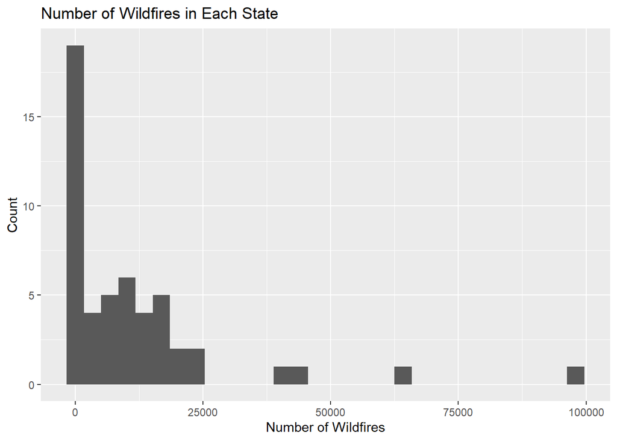

```r
## create histogram of frequency of fires to check the spread _____________

# create histogram
wf %>%
  group_by(`STATE`) %>%
  summarize(
    `NUMBER` = n()
  ) %>%
  ggplot(wf, mapping = aes(
    x = `NUMBER`
  )) +
  geom_histogram() +
  labs(
    title = "Number of Wildfires in Each State",
    x = "Number of Wildfires",
    y = "Count"
  )
```

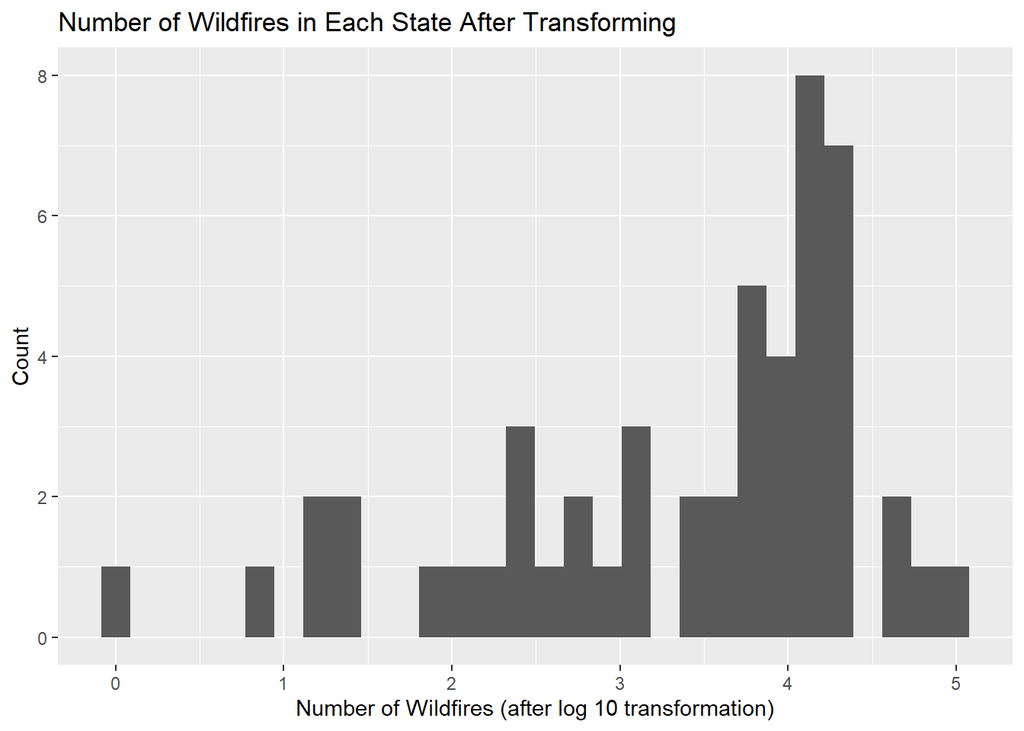

```r
# create histogram
wf %>%
  group_by(`STATE`) %>%
  summarize(
    `NUMBER` = n()
  ) %>%
  ggplot(wf, mapping = aes(
    x = log10(`NUMBER`)
  )) +
  geom_histogram(bins = 30) +
  labs(
    title = "Number of Wildfires in Each State After Transforming",
    x = "Number of Wildfires (after log 10 transformation)",
    y = "Count"
  )
```

The intensity and frequeny of the wildfires were then used to help determine if there was variability in the different months and states wildfire measurements. The determination of variability ensures that there is a need for a prediction model, as otherwise, a national average could have been used instead to imply an equal spread of incidence across all the states and months within the U.S.

To determine variability, the data was grouped by `STATE` and `MONTH`, then `STATE` agin to determine a monthly average for median size and number of wildfires for each state. A scatterplot was then created to see if there was any variability. The scatterplot shows that there is variability in the wildfires’ intensity and frequency due to differing time and space. Each point represents a State’s monthly average median size and number of wildfires. There were certain points that were noticeably different than the others. Such as CT, Connecticut and GA, Georgia that were located at opposite ends, and showing that they had very high intensity and frequency respectively. Their points were located far from a good portion of other states that had a low value for both incidence variables. Despite a majority of the states hovering around one another with low values in frequency and intensity, there were little to no overlapping points. This shows that the data has variability when measuring the incidence of wildfire observations according to `STATE` and `MONTH` variables.

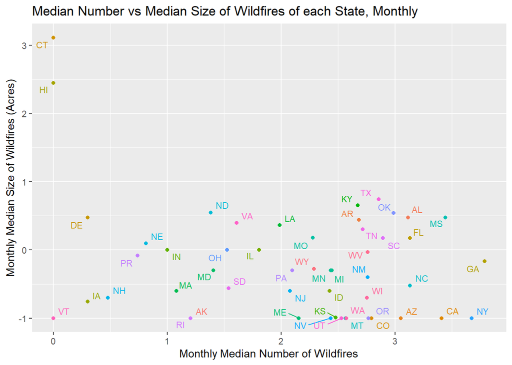

```r
## create scatterplot of intensity vs frequency of wildfires ___________________________

# prepare data for graphing
wf_freq_int <- wf %>%
  # group by state then year
  # stacks grouping to prepare for second grouping
  group_by(`STATE`, `MONTH`) %>%
  summarize(
    # count number of fires
    `NUM_PER_MONTH` = n(),
    # find median size of fires per year
    `MED_FIRE_SIZE_PER_MONTH` = median(`FIRE_SIZE`),
    .groups = "drop"
  ) %>%
  # group by state
  group_by(`STATE`) %>%
  summarize(
    # find median number of fires per year
    `MED_NUM_PER_STATE` = median(`NUM_PER_MONTH`),
    # find median size of fires per year
    `MED_FIRE_SIZE_PER_STATE` = median(`MED_FIRE_SIZE_PER_MONTH`)
  )
# check
# head(wf_freq_int)

# create scatterplot
wf_freq_int %>%
  ggplot(mapping = aes(
    x = log10(`MED_NUM_PER_STATE`),
    y = log10(`MED_FIRE_SIZE_PER_STATE`),
    # color each state a different color to differentiate
    color = `STATE`
    )) +
  # hide legend
  geom_point(show.legend = FALSE) +
  # separate the points and labels
  geom_text_repel(mapping = aes(
    # label each point by state
    label = `STATE`
  ),
  # hide legend
  show.legend = FALSE,
  # set size of labels
  size = 3) +
  # set labels
  labs(
    title = "Median Number vs Median Size of Wildfires of each State, Monthly",
    x = "Monthly Median Number of Wildfires",
    y = "Monthly Median Size of Wildfires (Acres)"
  )
```

Such variability in the location (State), and time (Month), guided me in the determination of which predictors to create and use for the prediction model. A new dataset, “st_wf” was created to as a summary table to highlight the predictor varaibles:

- `FIRE_OCC`: Number of noteable wildfires that occurred in the month.
- `PREV_1`: Whether there was a notable wildfire (1) or not (0) in the previous month.
- `PREV_3`: Whether there was a notable wildfire (1) or not (0) in the past three months.
- `AVG_LONG`: Average longitude of where fire was located in the state, measured in degrees.
- `AVG_LAT`: Average latitude of where fire was located in the state, measured in degrees.

The summary table dataset also included `FIRE_YEAR` and `MONTH` for further computations.

```r
## create final dataset summary table __________________________

avg_long_lat <- wf %>%
  group_by(`STATE`) %>%
  summarize(
    `AVG_LONG` = mean(`LONGITUDE`, na.rm = TRUE),
    `AVG_LAT` = mean(`LATITUDE`, na.rm = TRUE),
    .groups = "drop"
  )
# check
# head(avg_long_lat)

# add new averages to dataset
fetus_st_wf <- wf %>%
  left_join(avg_long_lat, by = "STATE")
# check
# head(wf)

# create new dataset (grid) in space-time units of state for every month and year
# `FIRE_OCC`: notable fire occured during the month
st_wf <- fetus_st_wf %>%
  group_by(`STATE`, `FIRE_YEAR`, `MONTH`, `AVG_LONG`, `AVG_LAT`) %>%
  summarize(
    FIRE_OCC = max(`IS_NOTABLE`, na.rm = TRUE),
    .groups = "drop"
  )
# check
# head(st_wf)

# add columns for predictors `PREV_1` and `PREV_3`
st_wf <- st_wf %>%
  # arrange according to `STATE` -> `YEAR` -> `MONTH` to apply lag
  arrange(`STATE`, `FIRE_YEAR`, `MONTH`) %>%
  group_by(`STATE`) %>%
  mutate(
    PREV_1 = lag(`FIRE_OCC`, 1, default = 0),
    PREV_3 = rollapplyr(`FIRE_OCC`, width = 3, FUN = sum, fill = 0)
  )
# check
head(st_wf)
```

```
## # A tibble: 6 × 8
## # Groups:   STATE [1]
##   STATE FIRE_YEAR MONTH AVG_LONG AVG_LAT FIRE_OCC PREV_1 PREV_3
##   <chr>     <dbl> <dbl>    <dbl>   <dbl>    <dbl>  <dbl>  <dbl>
## 1 AK         1997     5    -143.    59.8        0      0      0
## 2 AK         2004     8    -143.    59.8        0      0      0
## 3 AK         2005     3    -143.    59.8        0      0      0
## 4 AK         2005     4    -143.    59.8        1      0      1
## 5 AK         2005     5    -143.    59.8        0      1      1
## 6 AK         2005     6    -143.    59.8        0      0      1
```

### 2. Exploratory Data Analysis

The purpose of this section is to build intuition about the data and to justify modeling decisions.

To picture the variability between the states of the wildfires, it felt most natural to plot a heatmap in the shape of the United States. The coloring was determined by the median size (intensity) and median number (frequency) of the wildfires. The lower the value, the more purple the coloring, and the higher the value, the more yellow the color of the area becomes. To do this, the data was organized according to each state for each month, regardless of which year. Then, in the creation of each heatmap, the data was faceted according to `MONTH`. This meant that there would be 12 panels, one for each month of the year.

The heatmap for the frequency of wildfires focuses on the median number of wildfires for each state and month, regardless of the year. Something to note however, is that the data has been transformed by log 10 to make potential patterns more apparent. The heatmaps show a couple of patterns. The months during the beginning and end of the year: January, February, November, and December appear the most similar. March looks like a hybrid between April, May, and October. While June and September look fairly identical, and July and August look similar with the most amount of yellow in their heatmaps. Typically, as the year progresses through the middle, the left region of the country and bottom right show the largest median number of wildfires. These results show that the frequency of wildfires changes throughout the year and months, and across states.The difference between the months at the edges of the year and those in the middle are very stark, showing strong seasonality. The pairings of the months’ similarities follow a pattern similar to that of the seasons seen in the U.S. Such as, the expectation that in the summer, the weather becomes much warmer and dryer, creating a more ideal environment for wildfires can be seen reflected in the much higher yellow coloring seen in the months June, July, and August.

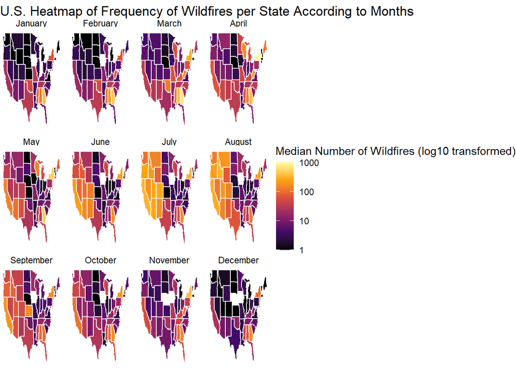

```r
## create heatmap to show frequency of fires based on location _____________

# create labels for each month for the heatmaps
months_labels <- setNames(month.name, 1:12)

# prepare new dataset for graphing
wf_freq <- wf %>%
  mutate(
    # set names to equal the states dataset
    `STATE_LOWER` = tolower(state.name[match(`STATE`, state.abb)])
  ) %>%
  # filter out any na values
  filter(!is.na(`STATE_LOWER`)) %>%
  group_by(`STATE_LOWER`, `FIRE_YEAR`, `MONTH`) %>%
  summarize(
    # number of wildfires for each month for each year
    `NUM_FIRE` = n(),
    .groups = "drop"
  ) %>%
  group_by(`STATE_LOWER`, `MONTH`) %>%
  summarize(
    # median number of wildfires for each month for all years
    `MED_NUM_FIRE` = median(`NUM_FIRE`),
    .groups = "drop"
  )
# check
# head(wf_freq)

# load in us states data
us_states <- map_data("state")
# check
# glimpse(us_states)
# head(us_states)

# combine graphing dataset and states dataset
wf_freq_states <- left_join(us_states,
                              wf_freq,
                              by = c("region" = "STATE_LOWER")) %>%
  filter(!is.na(`MONTH`)) %>%
  arrange(order)

# check
# head(wf_freq_states)

# plot heatmap of the us
ggplot(data = wf_freq_states, mapping = aes(
  x = long,
  y = lat,
  # create heatmap based on number of fires per month of the state
  fill = `MED_NUM_FIRE`,
  group = group
)) +
  # create general shape of the country
  geom_polygon(color = "white") +
  scale_fill_viridis_c(option = "inferno",
                       # transform the data to bring out variation
                       trans = "log10") +
  # facet according to month
  facet_wrap(~ `MONTH`,
             labeller = labeller(`MONTH` = months_labels)) +
  # make graph look cleaner
  theme_void() +
  # labels
  labs(
    title = "U.S. Heatmap of Frequency of Wildfires per State According to Months",
    # label the legend
    fill = "Median Number of Wildfires (log10 transformed)",
  )
```

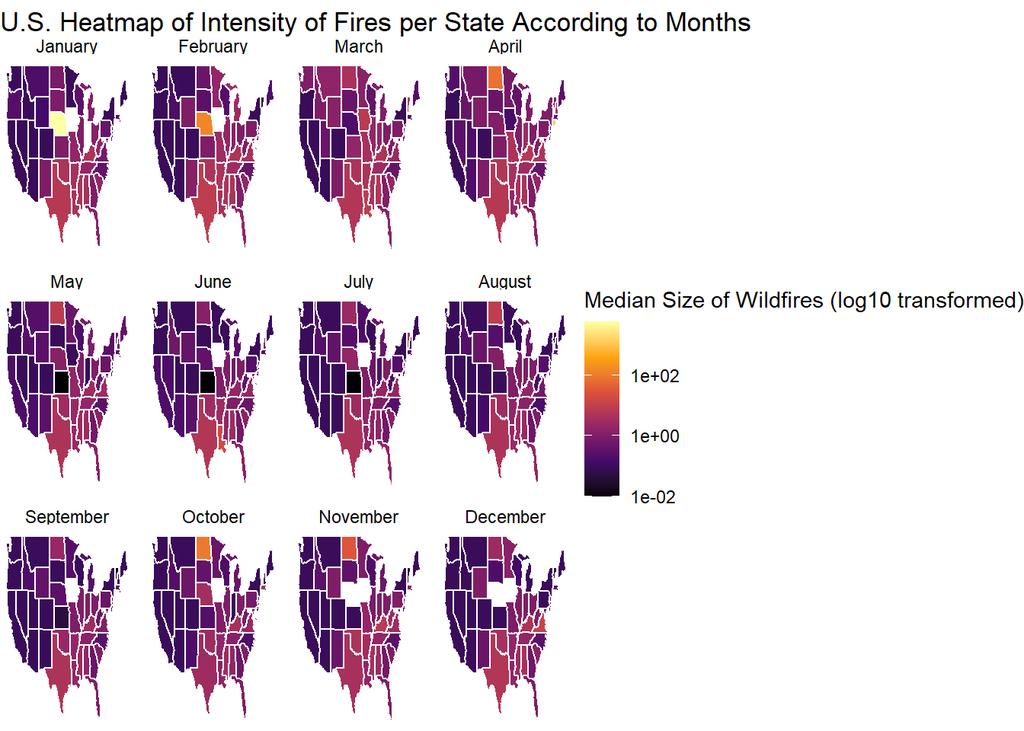

```r
## create heatmap to show intensity of fires based on location _____________

# prepare new dataset for graphing
wf_int <- wf %>%
  mutate(
    # set names to equal the states dataset
    `STATE_LOWER` = tolower(state.name[match(`STATE`, state.abb)])
  ) %>%
  # filter out any na values
  filter(!is.na(`STATE_LOWER`)) %>%
  group_by(`STATE_LOWER`, `MONTH`) %>%
  summarize(
    # number of wildfires
    `MED_FIRE_SIZE` = median(`FIRE_SIZE`),
    .groups = "drop"
  )
# check
# head(wf_int)

# combine graphing dataset and states dataset
wf_int_states <- left_join(us_states,
                              wf_int,
                              by = c("region" = "STATE_LOWER")) %>%
  filter(!is.na(`MONTH`)) %>%
  arrange(order)

# plot heatmap of the us
ggplot(data = wf_int_states, mapping = aes(
  x = long,
  y = lat,
  # create heatmap based on average fire size per state
  fill = `MED_FIRE_SIZE`,
  group = group
)) +
  # create general shape of the country
  geom_polygon(color = "white") +
  scale_fill_viridis_c(option = "inferno",
                       # transform the data to bring out variation
                       trans = "log10") +
  # facet according to month
  facet_wrap(~ `MONTH`,
             labeller = labeller(`MONTH` = months_labels)) +
  # make graph look cleaner
  theme_void() +
  # labels
  labs(
    title = "U.S. Heatmap of Intensity of Fires per State According to Months",
    # label the legend
    fill = "Median Size of Wildfires (log10 transformed)",
  )
```

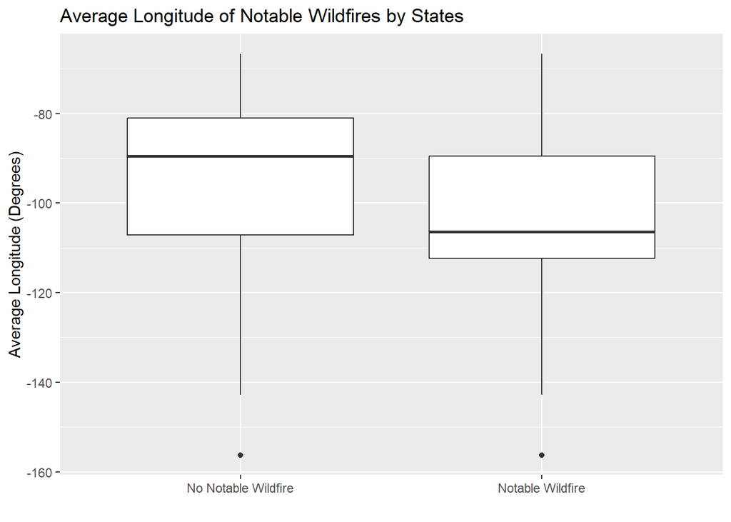

```r
## create graphs to explore relationship between predictors and notable fire and non-fire observations ________________________________

# boxplot of `AVG_LONG` vs `FIRE_OCC`
st_wf %>%
  ggplot(mapping = aes(
    x = as.factor(`FIRE_OCC`),
    y = `AVG_LONG`
    )) +
  geom_boxplot() +
  scale_x_discrete(
    labels = c(
      "0" = "No Notable Wildfire",
      "1" = "Notable Wildfire"
    )
  ) +
  labs(
    title = "Average Longitude of Notable Wildfires by States",
    x = "",
    y = "Average Longitude (Degrees)"
  )
```

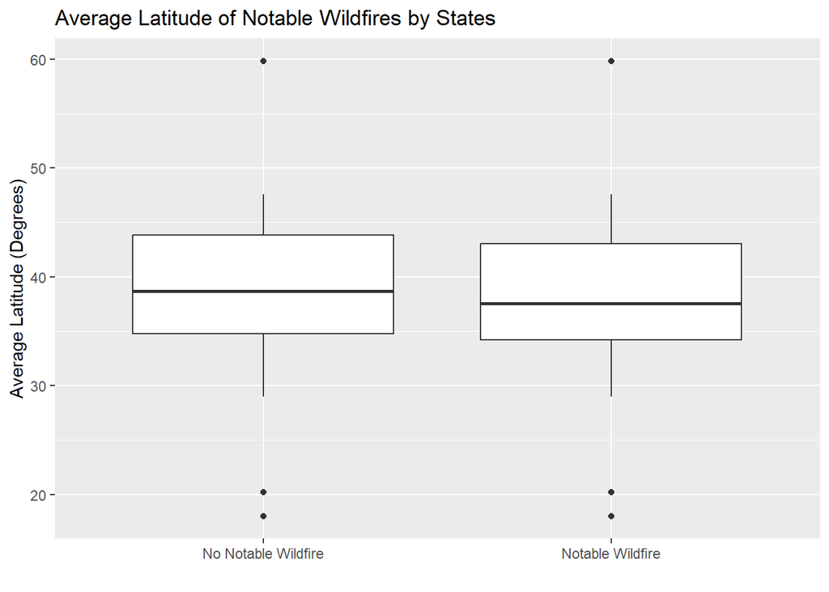

```r
# boxplot of `AVG_LAT` vs `FIRE_OCC`
st_wf %>%
  ggplot(mapping = aes(
    x = as.factor(`FIRE_OCC`),
    y = `AVG_LAT`
    )) +
  geom_boxplot() +
  scale_x_discrete(
    labels = c(
      "0" = "No Notable Wildfire",
      "1" = "Notable Wildfire"
    )
  ) +
  labs(
    title = "Average Latitude of Notable Wildfires by States",
    x = "",
    y = "Average Latitude (Degrees)"
  )
```

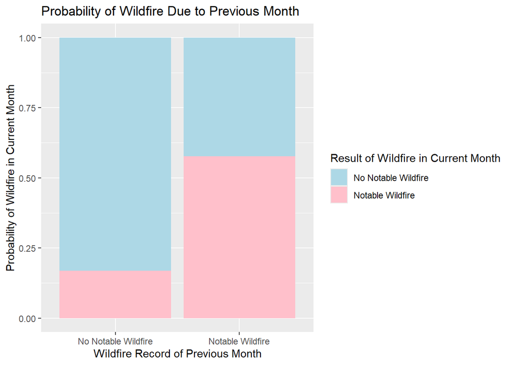

```r
# bar chart of `PREV_1` vs `FIRE_OCC`
st_wf %>%
  ggplot(mapping = aes(
    x = as.factor(`PREV_1`),
    fill = as.factor(`FIRE_OCC`)
  )) +
  geom_bar(position = "fill") +
  scale_x_discrete(
    labels = c(
      "0" = "No Notable Wildfire",
      "1" = "Notable Wildfire"
    )) +
  scale_fill_manual(
    values = c(
      "0" = "lightblue",
      "1" = "pink"
    ),
    labels = c(
      "0" = "No Notable Wildfire",
      "1" = "Notable Wildfire"
    )) +
  labs(
    title = "Probability of Wildfire Due to Previous Month",
    x = "Wildfire Record of Previous Month",
    y = "Probability of Wildfire in Current Month",
    fill = "Result of Wildfire in Current Month"
  )
```

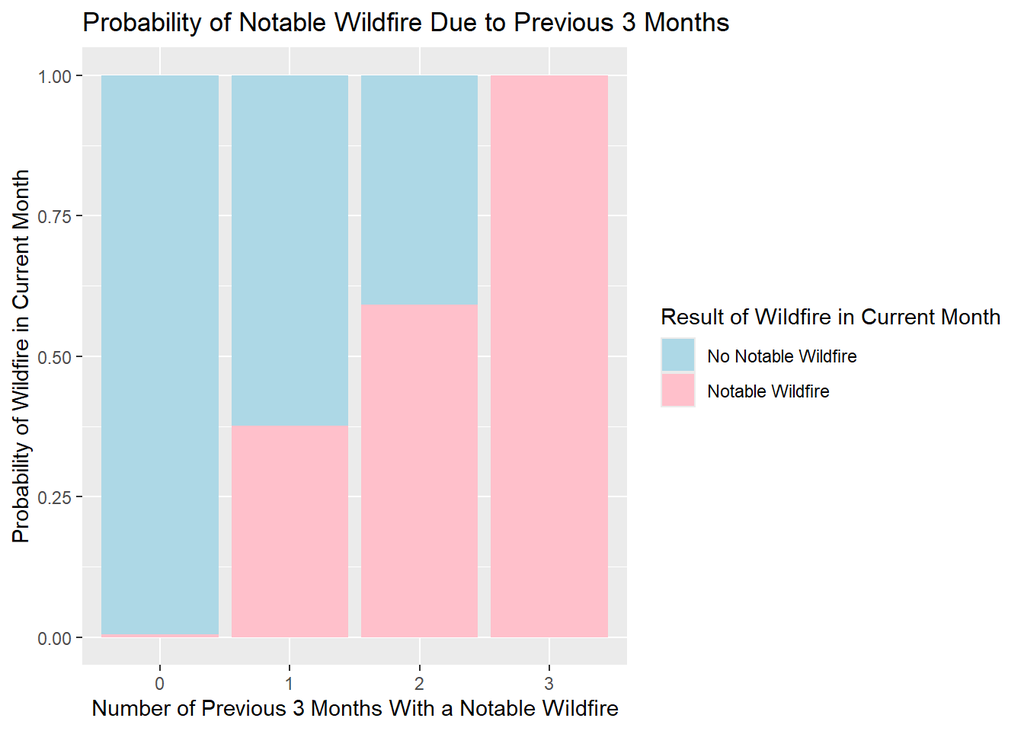

```r
# bar chart of `PREV_3` vs `FIRE_OCC`
st_wf %>%
  ggplot(mapping = aes(
    x = as.factor(`PREV_3`),
    fill = as.factor(`FIRE_OCC`)
  )) +
  geom_bar(position = "fill") +
  scale_fill_manual(
    values = c(
      "0" = "lightblue",
      "1" = "pink"
    ),
    labels = c(
      "0" = "No Notable Wildfire",
      "1" = "Notable Wildfire"
    )) +
  labs(
    title = "Probability of Notable Wildfire Due to Previous 3 Months",
    x = "Number of Previous 3 Months With a Notable Wildfire",
    y = "Probability of Wildfire in Current Month",
    fill = "Result of Wildfire in Current Month"
  )
```

### 3. Modeling

This section specifies and justifies the fitting of two models: a baseline model and a chosen model.

The baseline model that was chosen is a logistic regression model due to the response variable, `FIRE_OCC`’s nature to accept only values of 0 (no notable wildfires within the month), or 1 (at least one notable wildfire within the month). Since logistic regression assumes a linear relationship between the predictors and the log-odds of a new wildfire of occurring. The probability function $f(x)$ of the model is shown below:

$f(x) = \frac{e^{\beta_{0} + \beta_{1}(PREV\_1) + \beta_{2}(PREV\_3) + \beta_{3}(AVG\_LONG) + \beta_{4}(AVG\_LAT)}}{1 + e^{\beta_{0} + \beta_{1}(PREV\_1) + \beta_{2}(PREV\_3) + \beta_{3}(AVG\_LONG) + \beta_{4}(AVG\_LAT)}}$

The model that I chose is the random forest model. A random forest model uses many decision trees that are compiled from different and random parts of the training data. Each tree makes a decision based on the random columns it picks to split the data. The model follows a specific order. It first takes the training data and takes a number $n$ amount of bootstrap samples, or random subsets of the data. It then uses the samples to create decision trees for each to make a prediction based on the data within their samples. The decisions from each tree are then aggregated, and the decision that appears in most decision trees will be the final result. The random forest model follows the schematic:

[output not shown]

In which: - dec. tree = decision tree - pred. = prediction - agg. = aggregation

Since logistic regression relies on the linear relationship, the random forest will account for the potential non-linear aspects that was missed. This decision was mainly due to the sort of increasing, but non-linear probability that was seen in the bar chart for the `PREV_3` predictor variable.

```r
## fit the baseline model ________________________________

# set up the data to be the training data
wf_train <- st_wf %>%
  filter(`FIRE_YEAR` <= 1996)

# fit the training data into logistic regression
wf_lg <- glm(`FIRE_OCC` ~ `PREV_1` + `PREV_3` + `AVG_LONG` + `AVG_LAT`,
             data = wf_train,
             family = "binomial")

# see summary
summary(wf_lg)
```

```
##
## Call:
## glm(formula = FIRE_OCC ~ PREV_1 + PREV_3 + AVG_LONG + AVG_LAT,
##     family = "binomial", data = wf_train)
##
## Coefficients:
##              Estimate Std. Error z value Pr(>|z|)
## (Intercept) -4.600401   1.504233  -3.058  0.00223 **
## PREV_1      -3.920129   0.619884  -6.324 2.55e-10 ***
## PREV_3       4.029147   0.446988   9.014  < 2e-16 ***
## AVG_LONG    -0.007103   0.012266  -0.579  0.56251
## AVG_LAT     -0.004217   0.030908  -0.136  0.89147
## ---
## Signif. codes:  0 '***' 0.001 '**' 0.01 '*' 0.05 '.' 0.1 ' ' 1
##
## (Dispersion parameter for binomial family taken to be 1)
##
##     Null deviance: 530.36  on 506  degrees of freedom
## Residual deviance: 253.47  on 502  degrees of freedom
## AIC: 263.47
##
## Number of Fisher Scoring iterations: 6
```

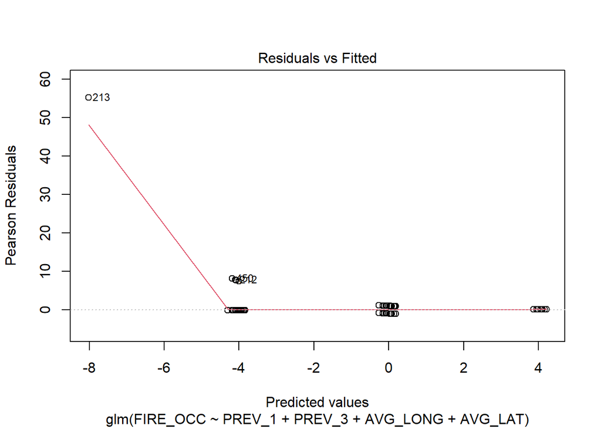

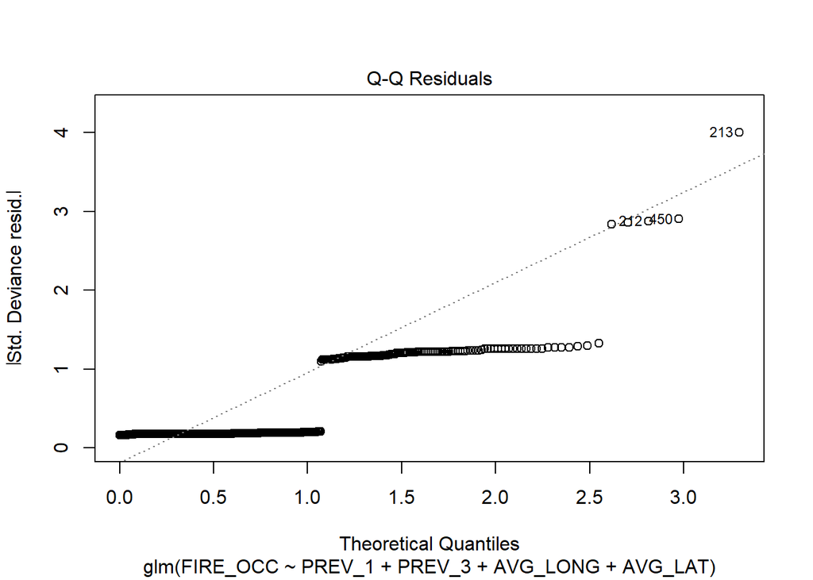

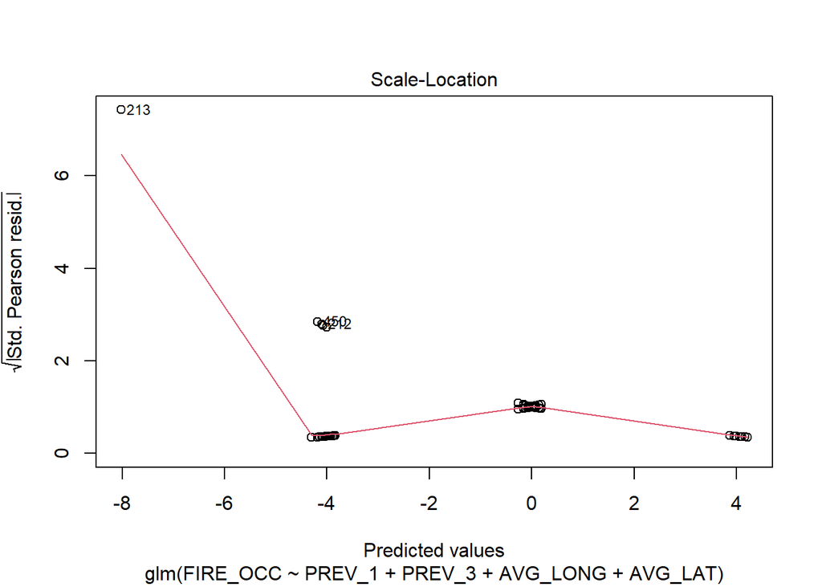

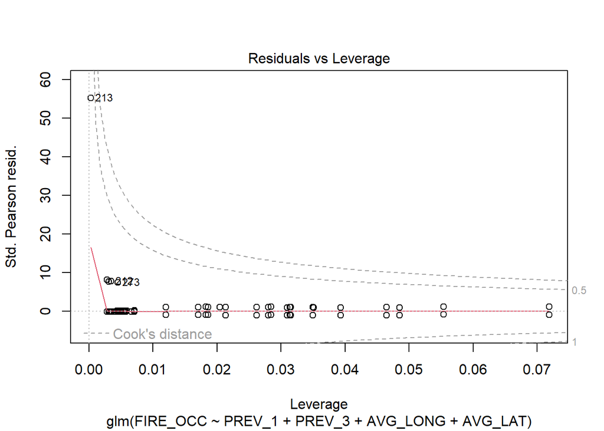

```r
# plot the model
plot(wf_lg)
```

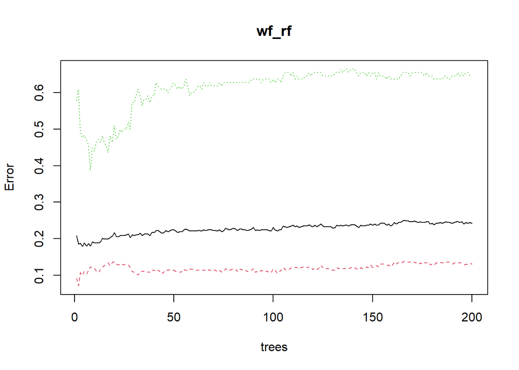

```r
## fit chosen model ______________________________________

# fit the data into random forest model
wf_rf <- randomForest(as.factor(`FIRE_OCC`) ~ `PREV_1` + `PREV_3` + `AVG_LONG` + `AVG_LAT`,
                      ntree = 200,
                      data = wf_train,
                      importance = TRUE)

# plot the model
plot(wf_rf)
```

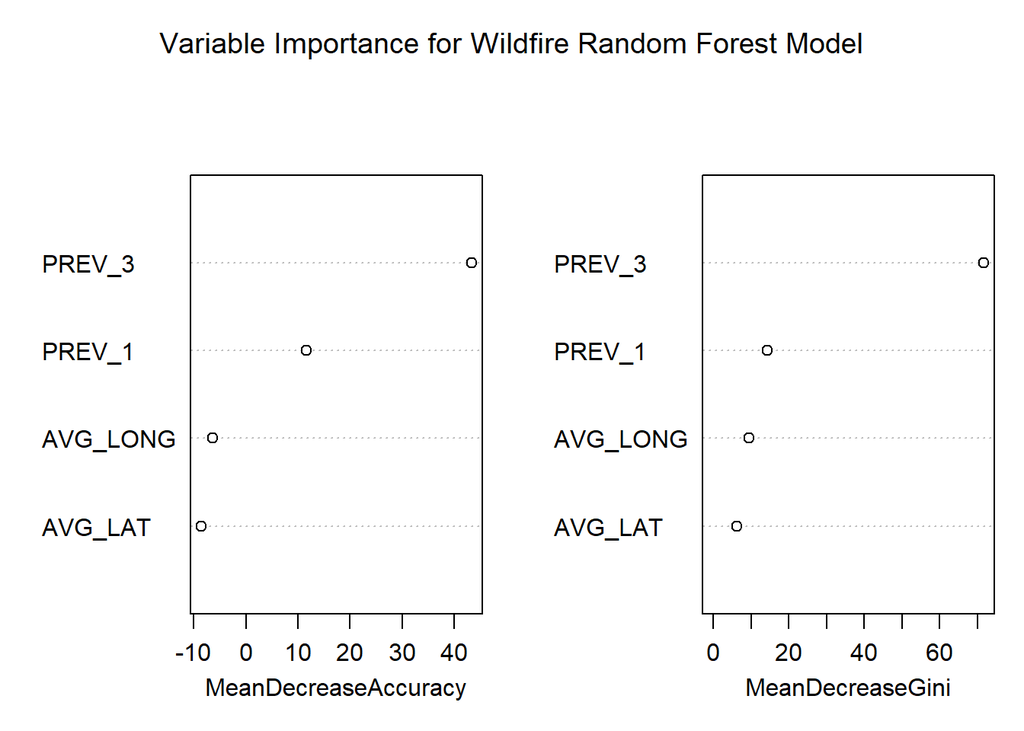

```r
# plot variable importance plot
varImpPlot(wf_rf, main = "Variable Importance for Wildfire Random Forest Model")
```

### 4. Model Fitting and Validation

This section evaluates how well the models fit historical data and how they generalize over time.

The model avoids data leakage that would predict outcomes in the past using future data for training. The model only contains predictors that do not rely on data that is determined after the wildfires occur. In addition, both the logistic regression and random forest model were trained on the first five years of the dataset from 1992 to 1996. For each year following the initial five, the models predict the number of notable wildfire observations for year $t + 1$ using a set of data. Such set of data is the training set that contains the data of all the years before $t$.

The evaluation metric used to determine the effectiveness of the models is the Area Under the ROC Curve (AUC). This metric was used because it evaluates the model’s ability to correctly rank each month accordingly to the correct `FIRE_OCC` value, regardless of the overall low frequency that a wildfire has of occurring throughout all the months and states. Another reason why AUC is better used for evaluating both models is because it represents the performances of both models across all thresholds. As mentioned at the beginning of the project, the threshold was chosen so that notable wildfires were considered as those with a `FIRE_SIZE` of at least 300 acres. This was only possible due to the nature of the AUC metric. Otherwise, the threshold would have had to been fixed.

To evaluate the performance of the random forest model, a variable importance plot was created. The variable importance plot ranks the predictors based on how much removal of the predictor’s data decreases the model’s accuracy. The ordering shows that predictors `PREV_3` and `PREV_1` decrease most the model’s accuracy when their data are removed. This allows the assumption that they are the most appropriate predictors for the model compared to the `AVG_LONG` and `AVG_LANG` predictors.

```r
## run test data to compare models ______________________________

# split off the test data
wf_test <- st_wf %>%
  filter(`FIRE_YEAR` > 1996)
# check
head(wf_test)
```

```
## # A tibble: 6 × 8
## # Groups:   STATE [1]
##   STATE FIRE_YEAR MONTH AVG_LONG AVG_LAT FIRE_OCC PREV_1 PREV_3
##   <chr>     <dbl> <dbl>    <dbl>   <dbl>    <dbl>  <dbl>  <dbl>
## 1 AK         1997     5    -143.    59.8        0      0      0
## 2 AK         2004     8    -143.    59.8        0      0      0
## 3 AK         2005     3    -143.    59.8        0      0      0
## 4 AK         2005     4    -143.    59.8        1      0      1
## 5 AK         2005     5    -143.    59.8        0      1      1
## 6 AK         2005     6    -143.    59.8        0      0      1
```

```r
# predict probability using logistic regression model
wf_lg_pred <- predict(wf_lg,
                      newdata = wf_test,
                      type = "response")

# predict probability using random forest model
wf_rf_pred <- predict(wf_rf,
                      newdata = wf_test,
                      # want only a column
                      type = "prob")[, "1"]

# create roc
wf_lg_roc <- roc(wf_test$FIRE_OCC, wf_lg_pred)
wf_rf_roc <- roc(wf_test$FIRE_OCC, wf_rf_pred)
# get the auc scores
auc(wf_lg_roc)
```

```
## Area under the curve: 0.9393
```

```r
auc(wf_rf_roc)
```

```
## Area under the curve: 0.9414
```

### 5. Summary

This section summarizes the main findings and contributions of the project. Key insights obtained from the exploratory data analysis and what the predictive models are able to capture are also explained.

The United States is a large land full of forests and trees, yet also not enough. This is largely due to human activities such as over-harvesting lumber, or the burning of trees for more livable land. However, this is not to say that there are natural disasters at play, and even human-made ones too. One very notable kind of these disasters is wildfires. To prevent more disastrous loss to the forests, grass, and trees, preventative measures and remedies can be put into place. To make such measures possible, a predictive element must be included to help mitigate or entirely prevent. This is where a prediction model can be applied. By using predictor variables such as determining factors to help predict where the potential next wildfires could be based on a large database of collected data on such wildfires.

Through exploratory data analysis (EDA), it became possible to verify variability through different wildfire incidence and seasonality in the data for the different states and months. The wildfire incidence focused on the frequency and intensity of the wildfires, showing patterns. One such pattern was the higher frequency of wildfires in the western region during the months that were typically assumed as the summer. Another pattern is the noticeable intensity of wildfires within certain states such as North Dakota, or the lack of in states such as Nebraska and Iowa. The states and month were the chosen space-time units to be used as a measurement for the response variable `FIRE OCC` in the prediction model. This is because the goal of the prediction model was to determine if a notable fire would occur in a chosen month of a chosen state.

With the conclusion above, it became possible to determine the predictors to use in the prediction model. Seeing as there was variety in the data due to different location and time, it felt best to create `AVG_LONG`, `AVG_LAT`, `PREV_3`, and `PREV_1`. They focused on the average location of wildfires and whether a notable wildfire occurred in the previous three to one months, respectively. Graphing the predictors helped better understand their relation to the data. It gave insight on the nonlinear aspects in certain predictors such as `PREV_3` which led to the decision to use a random forest prediction model as the chosen to go against the baseline logistic regression model.

```r
## fit each model and get the AUC values for each ___________________

# get each year in the dataset
years_sort <- sort(unique(st_wf$FIRE_YEAR))

# train on the first 5 years
train_years <- 5

# set target variable
target <- "FIRE_OCC"

# define the formula
formula <- as.factor(`FIRE_OCC`) ~ `PREV_1` + `PREV_3` + `AVG_LONG` + `AVG_LAT`

# run time-aware cross-validation
fold <- tibble(
  train_end = years_sort[(train_years):(length(years_sort) - 2)],
  valid_year = years_sort[(train_years + 1):(length(years_sort) - 1)]
) %>%
  mutate(
    # run auc measurement for logistic regression model
    auc_glm = map2_dbl(train_end,
                        valid_year,
                        function(tr_end, va_year) {
                          # filter the data
                          train <- st_wf %>%
                            filter(`FIRE_YEAR` <= tr_end)
                          valid <- st_wf %>%
                            filter(`FIRE_YEAR` == va_year)

                          # fit the model
                          fit <- glm(`FIRE_OCC` ~ `PREV_1` + `PREV_3` + `AVG_LONG` + `AVG_LAT`,
                                     data = train,
                                     family = "binomial")

                          p_hat <- predict(fit,
                                           newdata = valid,
                                           type = "response")

                          as.numeric(roc(valid[[target]],
                                         p_hat,
                                         quiet = TRUE)$auc)
                        }),

    # run auc measurement for random forest model
    auc_rf = map2_dbl(train_end,
                        valid_year,
                        function(tr_end, va_year) {
                          # filter the data
                          train <- st_wf %>%
                            filter(`FIRE_YEAR` <= tr_end)
                          valid <- st_wf %>%
                            filter(`FIRE_YEAR` == va_year)

                          # fit the model
                          fit <- randomForest(as.factor(`FIRE_OCC`) ~ `PREV_1` + `PREV_3` + `AVG_LONG` + `AVG_LAT`,
                                     data = train,
                                     importance = TRUE)

                          p_hat <- predict(fit,
                                           newdata = valid,
                                           type = "prob")[, "1"]

                          as.numeric(roc(valid[[target]],
                                         p_hat,
                                         quiet = TRUE)$auc)
                        }),

    # run auc measurement for decision tree model
    auc_rpart = map2_dbl(train_end,
                        valid_year,
                        function(tr_end, va_year) {
                          # filter the data
                          train <- st_wf %>%
                            filter(`FIRE_YEAR` <= tr_end)
                          valid <- st_wf %>%
                            filter(`FIRE_YEAR` == va_year)

                          # fit the model
                          fit <- rpart(as.factor(`FIRE_OCC`) ~ `PREV_1` + `PREV_3` + `AVG_LONG` + `AVG_LAT`,
                                     data = train,
                                     method = "class",
                                     control = rpart.control(cp = 0.01))

                          p_hat <- predict(fit,
                                           newdata = valid,
                                           type = "prob")[, "1"]

                          as.numeric(roc(valid[[target]],
                                         p_hat,
                                         quiet = TRUE)$auc)
                        }),

    # run auc measurement for xgboost model
    auc_xgb = map2_dbl(train_end,
                       valid_year,
                       function(tr_end, va_year) {
                          # filter the data
                          train <- st_wf %>% filter(`FIRE_YEAR` <= tr_end)
                          valid <- st_wf %>% filter(`FIRE_YEAR` == va_year)

                          # make sure the response variable is an integer
                          y_train <- as.integer(as.character(train$FIRE_OCC))

                          # create Matrix for predictors
                          x_train <- data.matrix(train[, c("PREV_1", "PREV_3", "AVG_LONG", "AVG_LAT")])
                          x_valid <- data.matrix(valid[, c("PREV_1", "PREV_3", "AVG_LONG", "AVG_LAT")])

                          # fit the model
                          fit <- xgboost(
                            data = x_train,
                            label = y_train,
                            nrounds = 50,
                            params = list(objective = "binary:logistic"),
                            verbose = 0)

                          p_hat <- predict(fit,
                                           newdata = x_valid)

                          as.numeric(roc(valid[[target]],
                                         p_hat,
                                         quiet = TRUE)$auc)
                          })

  )

fold
```

```
## # A tibble: 18 × 6
##    train_end valid_year auc_glm auc_rf auc_rpart auc_xgb
##        <dbl>      <dbl>   <dbl>  <dbl>     <dbl>   <dbl>
##  1      1996       1997   0.964  0.960     0.965   0.960
##  2      1997       1998   0.947  0.950     0.945   0.950
##  3      1998       1999   0.938  0.934     0.923   0.931
##  4      1999       2000   0.934  0.930     0.926   0.930
##  5      2000       2001   0.917  0.910     0.903   0.912
##  6      2001       2002   0.910  0.911     0.896   0.920
##  7      2002       2003   0.911  0.920     0.912   0.923
##  8      2003       2004   0.919  0.925     0.915   0.924
##  9      2004       2005   0.948  0.947     0.945   0.946
## 10      2005       2006   0.931  0.924     0.912   0.923
## 11      2006       2007   0.944  0.937     0.918   0.939
## 12      2007       2008   0.948  0.941     0.924   0.927
## 13      2008       2009   0.947  0.944     0.942   0.943
## 14      2009       2010   0.926  0.930     0.913   0.926
## 15      2010       2011   0.952  0.934     0.935   0.895
## 16      2011       2012   0.932  0.925     0.916   0.921
## 17      2012       2013   0.943  0.937     0.926   0.931
## 18      2013       2014   0.947  0.935     0.927   0.929
```

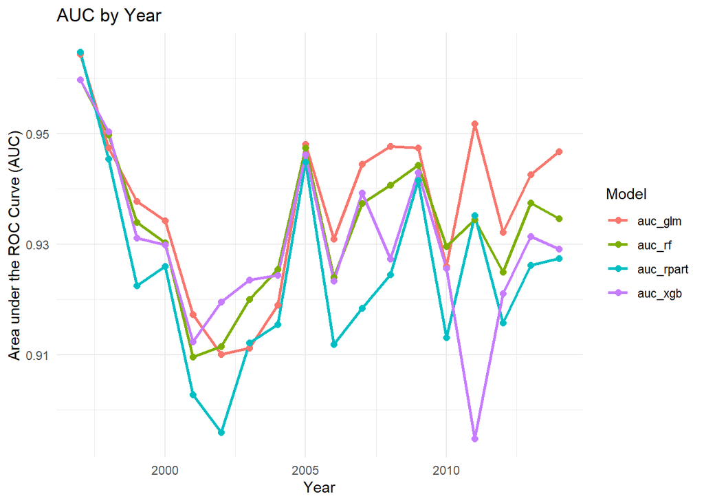

```r
## plot and print results _______________________________

# pivot results to be able to plot
fold_long <- fold %>%
  pivot_longer(
    cols = c(auc_glm, auc_rf, auc_rpart, auc_xgb),
    names_to = "model",
    values_to = "auc"
  )
# check
# fold_long

# create line plot
ggplot(fold_long, aes(x = valid_year, y = auc, color = model)) +
  geom_line(linewidth = 1) +
  geom_point(size = 2) +
  labs(
    title = "AUC by Year",
    x = "Year",
    y = "Area under the ROC Curve (AUC)",
    color = "Model"
  ) +
  theme_minimal()
```

```r
# print results comparing the auc values
cat('Overall, logistic regression outperforms random forests in AUC by ',
    round(mean(fold$auc_glm) / mean(fold$auc_rf) * 100, 2) - 100, "%", sep= '')
```

```
## Overall, logistic regression outperforms random forests in AUC by 0.38%
```